# CompitoJan2020-Births

Emanuele Lena - 142411@uniud

7/2/2022

```r
knitr::knit('Funzioni2.Rmd')
```

```
##
##
## processing file: Funzioni2.Rmd
```

[output not shown]

```
## output file: Funzioni2.md
```

```
## [1] "Funzioni2.md"
```

## Eda

```
## starting httpd help server ... done
```

The aim of the study is to analyze the potential relationship between the response variable bwt and the explanatory variables age and race. Describe how to perform a preliminary data analysis on this dataframe using suitable R commands and comment the following plots

Il dataset è costituito da 189 osservazioni e 10 variabili. Per quest’analisi le variabili d’interesse saranno bwt, age e race. Le altre variabili verranno temporaneamente accantonate.

```r
birthwt2 <- birthwt[, c("bwt", "age", "race")]
birthwt2$race <- factor(birthwt$race, levels = c(1,2,3), labels = c("white", "black", "other"))
summary.all(birthwt2)
```

```
## $bwt
##     Min.  1st Qu.   Median     Mean  3rd Qu.     Max.     Var.  StdDev.
##    709.0   2414.0   2977.0   2944.6   3487.0   4990.0 531753.5    729.2
##    Skew.    Kurt.
##     -0.2      2.9
##
## $age
##    Min. 1st Qu.  Median    Mean 3rd Qu.    Max.    Var. StdDev.   Skew.   Kurt.
## 14.0000 19.0000 23.0000 23.2381 26.0000 45.0000 28.0760  5.2987  0.7164  3.5684
##
## $race
## $race$Abs
## x
## white black other
##    96    26    67
##
## $race$Rel
## x
##     white     black     other
## 0.5079365 0.1375661 0.3544974
```

bwt è una variabile numerica continua, age è una numerica discreta (intera) e race è una categoriale nominale (non ordinale).

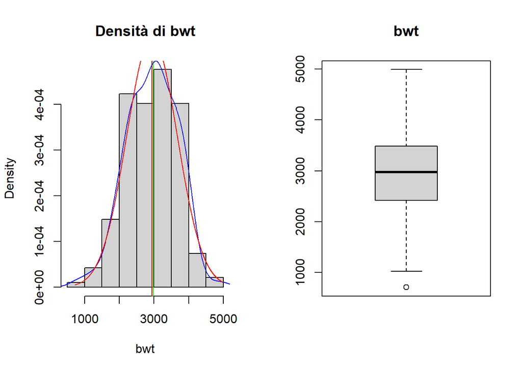

```r
par(mfrow=c(1,2))
gsummary.num("bwt", data=birthwt2, normCurve = T)
```

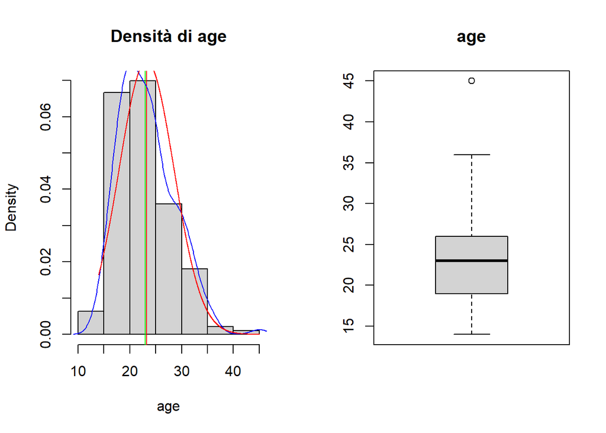

```r
gsummary.num("age", data=birthwt2, normCurve = T)
```

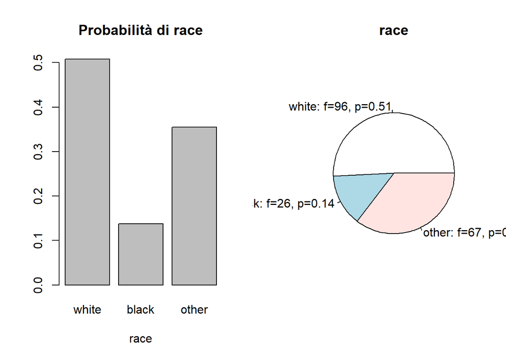

```r
gsummary.factor("race", data=birthwt2)
```

```r
par(mfrow=c(1,1))
```

bwt è caratteriz. da una curva di distribuzione a campana, vagamente simile ad una normale e caratterizzata da una bassa assimmetria e da una curtosi abbastanza vicina a quella di una normale. si osserva soltanto una coda sinistra un po’ più pesante e una destra leggera. Il boxplot segnala solo 1 potenziale outlyer a sinistra.

La curva di age è invece un po’ più assimmetrica, caratterizzata da code più pesanti (specialmente a destra) e non esattamente riconducibile ad una normale.

La categoriale race non è distribuita uniformamente, ma si hanno più del 50% delle osservazioni per white e forse un po’ poche per black.

```r
gsummary.norm("bwt", data=birthwt2,  stats = T, statsTest = T)
```

```
## [1] "NORMALITA' DI bwt"
##          Mean          Var.         Skew.         Kurt.
##  2.944587e+03  5.317535e+05 -2.069775e-01  2.886784e+00
##
## Title:
##  D'Agostino Normality Test
##
## Test Results:
##   STATISTIC:
##     Chi2 | Omnibus: 1.4335
##     Z3  | Skewness: -1.1927
##     Z4  | Kurtosis: -0.1045
##   P VALUE:
##     Omnibus  Test: 0.4883
##     Skewness Test: 0.233
##     Kurtosis Test: 0.9168
##
## Description:
##  Mon Feb 07 22:44:16 2022 by user: Proprietario
```

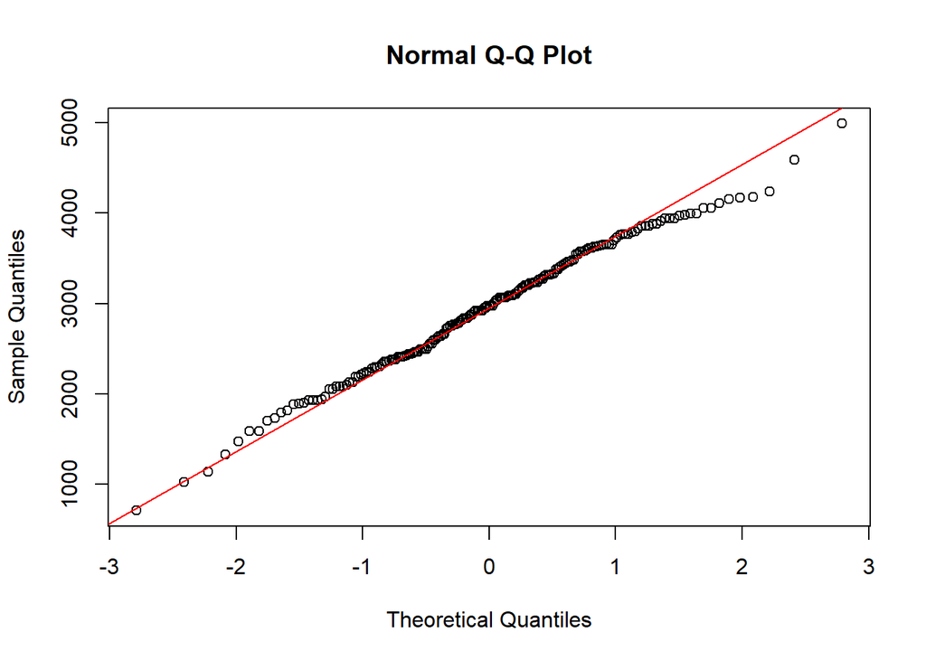

Gli indici di curtosi e assimmetria su bwt sono molto vicini a quelli di una normale.

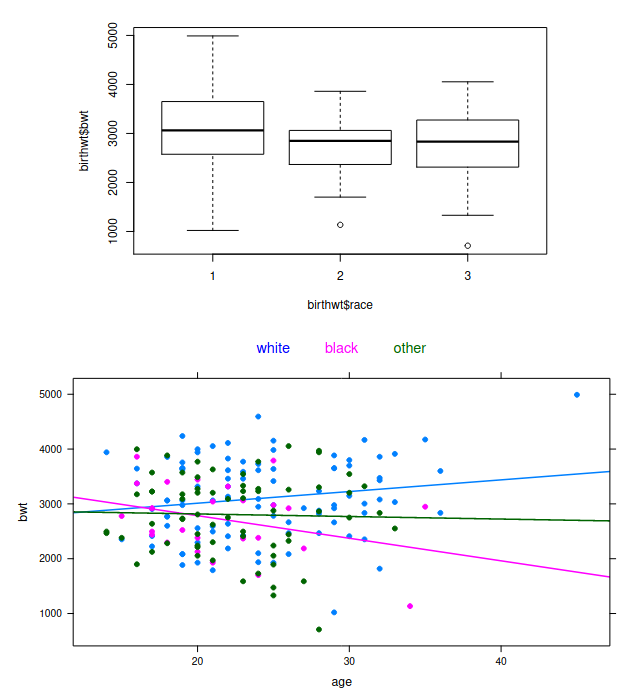

Sempre da tale grafico si osservano leggere differenze dei valori mediani, ma visto il discorso del campione piccolo, tali differenze potrebbero non essere rilevanti. Potrebbe essere interessante effettuare una comparazione delle medie campionarie tramite un test formale per verificarne la rilevanza.

```r
cor.check.factor.num("race", "bwt", data=birthwt2, stats = T)
```

```
## [1] "ANALISI PRELIMINARE DELLA CORRELAZIONE bwt ~ race"
## $Mean
##    white    black    other
## 3102.719 2719.692 2805.284
##
## $Median
## white black other
##  3062  2849  2835
##
## $Var.
##    white    black    other
## 529818.2 407917.1 521564.7
##
## $Std.Dev.
##    white    black    other
## 727.8861 638.6839 722.1944
```

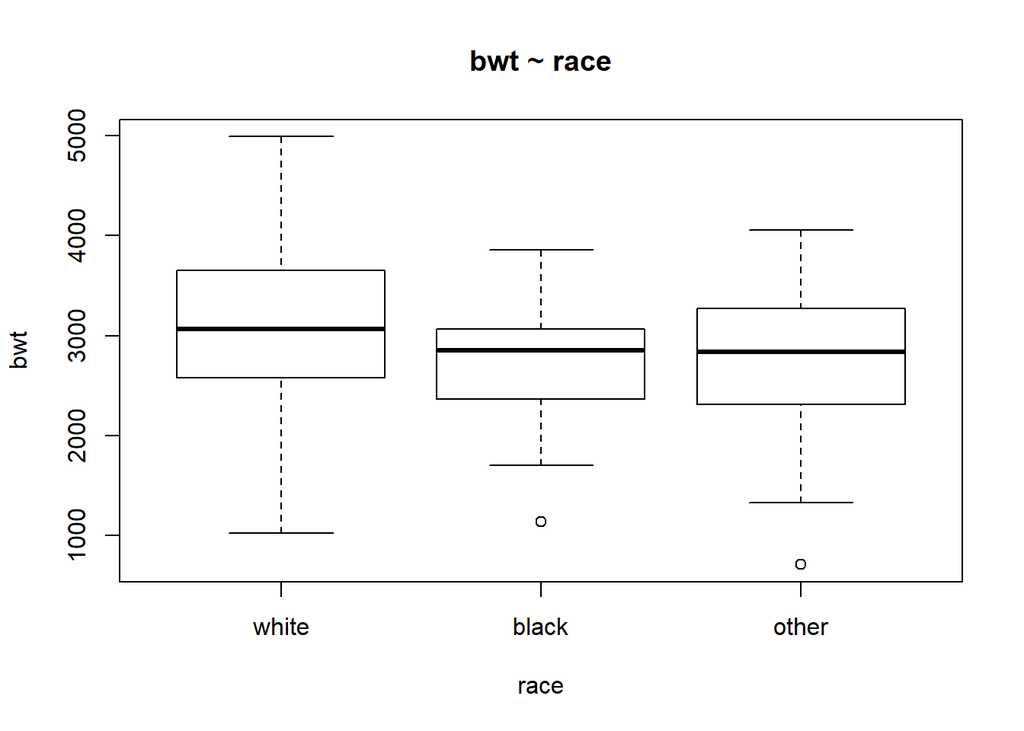

Nel secondo grafico invece si sono costruite tre rette di regressione bwt~age, una per ongi gruppo. Si osserva che le tre rette hanno pendenze diverse; in particolare, white cresce mentre others e black calano (la seconda in modo più vertiginoso). Ciò potrebbe essere indice di un’influenza di race su bwt, di un effetto combinato tra race ed age oppure semplicemente della mancanza di dati.

Sono necessarie ulteriori indagini.

## Analisi

In order to describe the potential relationship between birth weight and age, taking into account also the factor race, we compare the following nested models

```r
bwt.lm1 <- lm(bwt ~ 1 , data = birthwt)
bwt.lm2 <- lm(bwt ~ age, data = birthwt)
bwt.lm3 <- lm(bwt ~ race + age, data = birthwt)
bwt.lm4 <- lm(bwt ~ race*age, data = birthwt)
```

Describe the four models and comment the results given by the Analysis of Variance Table, reported below. Moreover, propose some alternative model selection procedures.

```r
anova(bwt.lm1, bwt.lm2, bwt.lm3, bwt.lm4)
```

```
## Analysis of Variance Table
##
## Model 1: bwt ~ 1
## Model 2: bwt ~ age
## Model 3: bwt ~ race + age
## Model 4: bwt ~ race * age
##   Res.Df      RSS Df Sum of Sq      F  Pr(>F)
## 1    188 99969656
## 2    187 99154173  1    815483 1.5908 0.20880
## 3    186 95848562  1   3305610 6.4485 0.01193 *
## 4    185 94833785  1   1014777 1.9796 0.16111
## ---
## Signif. codes:  0 '***' 0.001 '**' 0.01 '*' 0.05 '.' 0.1 ' ' 1
```

Si prova a stimare la variabile bwt con 3 (+1) modelli lineari. Il primo è semplicemente il modello nullo (usato più che altro come rifermento per la valutazione dei successivi). Il secondo tiene conto solo del regress. numerico age, il terzo prova ad introdurre il fattore race e il quarto considera entrambi le variabili esplicative + l’effetto iterazione.

Con la procedura Anova, si confrontano in successione (a coppie) i modelli. Nel confronto tra lm1 e lm2 si osserva un p-value piuttosto elevato, che indicherebbe che non c’è abbastanza certezza per affermare che esiste una correlazione lineare significativa tra age e bwt.

Let us consider Model 3 and comment the output obtained by the R functions summary and plot.

```
##
## Call:
## lm(formula = bwt ~ race + age, data = birthwt)
##
## Residuals:
##     Min      1Q  Median      3Q     Max
## -2104.8  -485.7    11.3   536.0  1746.4
##
## Coefficients:
##             Estimate Std. Error t value Pr(>|t|)
## (Intercept) 3028.482    277.679  10.906   <2e-16 ***
## race        -146.597     57.881  -2.533   0.0121 *
## age            8.039     10.032   0.801   0.4240
## ---
## Signif. codes:  0 '***' 0.001 '**' 0.01 '*' 0.05 '.' 0.1 ' ' 1
##
## Residual standard error: 717.9 on 186 degrees of freedom
## Multiple R-squared:  0.04122,    Adjusted R-squared:  0.03091
## F-statistic: 3.999 on 2 and 186 DF,  p-value: 0.01994
```

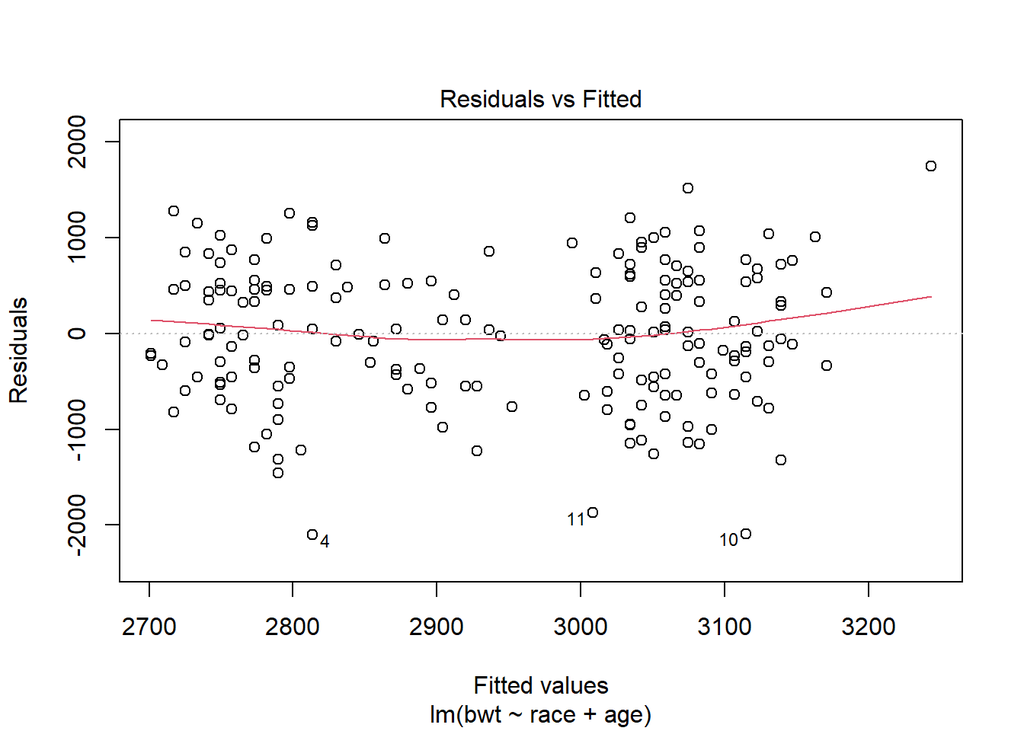

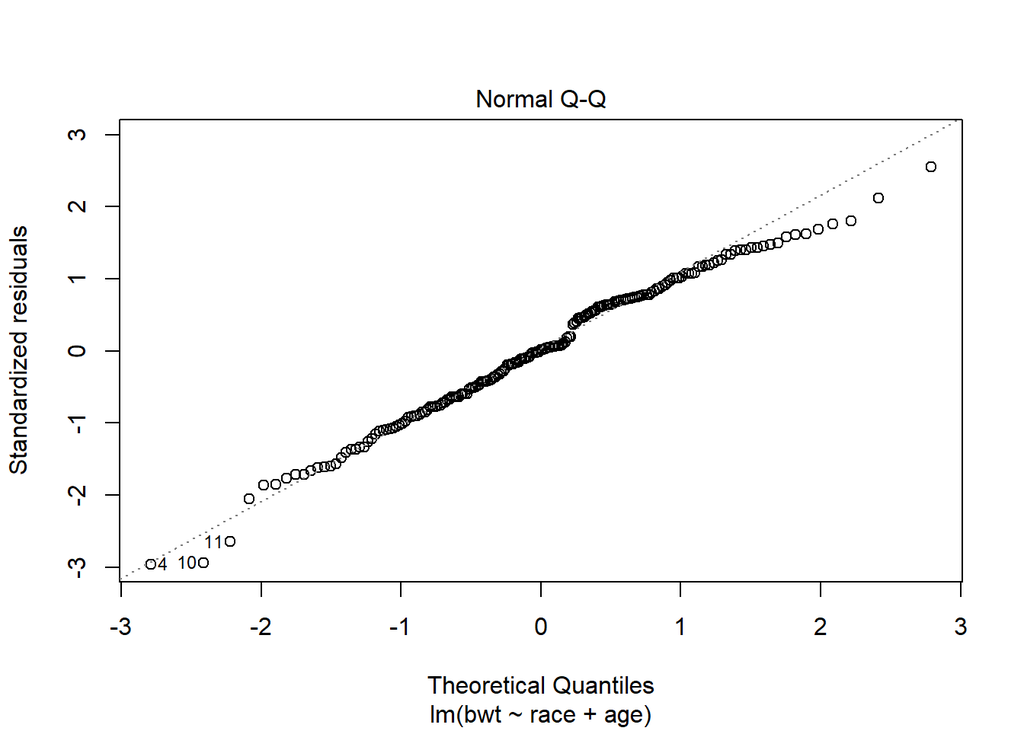

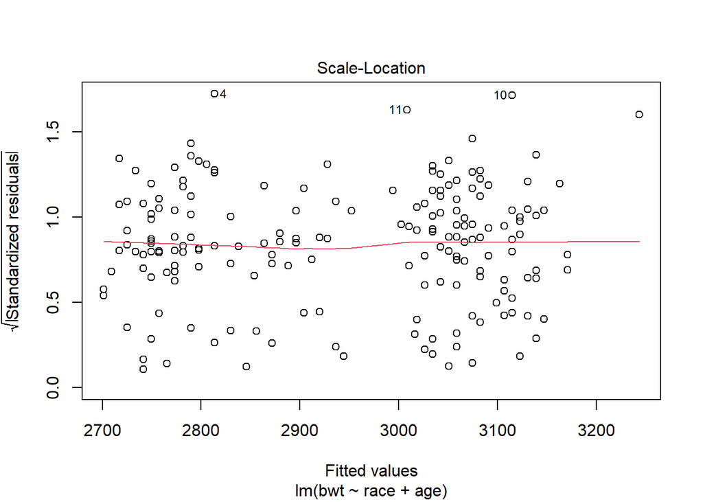

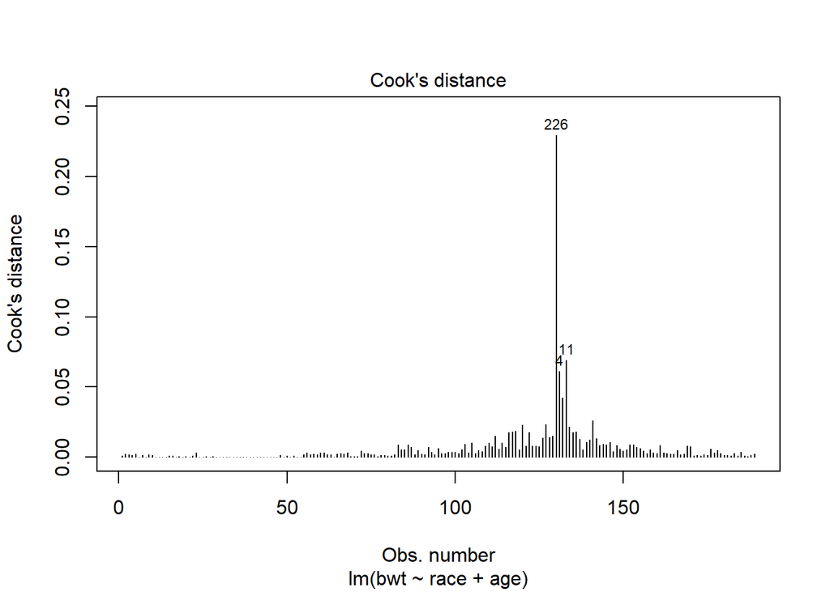

Confrontati alle statistiche di bwt, i residui sembrano elevati. L’indice R^2 così basso indica un’alta variabilità dei dati.

Dalle diagnostiche: * si osservano residui di variabilità abbastanza uniforme, ma raggruppati su due grossi cluster * non si osservano punti influenti particolarmente significiativi * il qq-plot presenta discostamenti sulle code

Finally, discuss the following graphical output and then suggest how to proceed with further analyses.

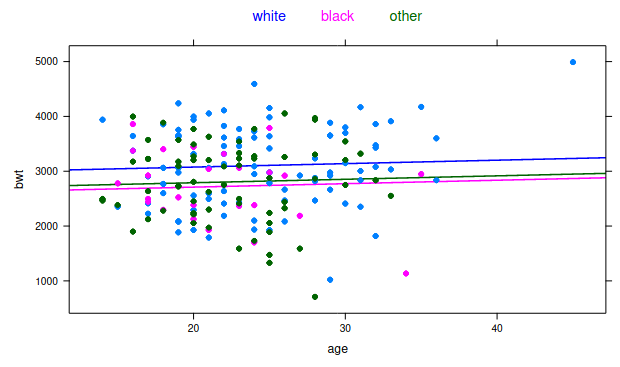

Detto ciò, si ribadisce quanto detto nell’analisi preliminare, cioè che probabilimente non ci sono abbastanza dati per effettuare un confronto significativo su queste variabili.

Per effettuare analisi ulteriori, si suggerisce di partire indagando sulle cause dei cluster nei residui, che probabilmente non stanno nelle variabili osservate. Pertanto si suggerisce di:

- studiare i residui parziali per age e race per verificare che i cluster non hanno origine da queste variabili
- eventualmente, estendere prima l’EDA e poi la scelta del modello alle altre variabili.
- se lo scopo dello studio è un confronto esclusivamente su queste variabili, si suggerisce di raccogliere un campione più significativo di dati

```r
birthwt3 <- birthwt

birthwt3$race <- factor(birthwt$race, labels = c("white", "black", "other"))
birthwt3$low <- factor(birthwt$low)
birthwt3$smoke <- factor(birthwt$smoke)
birthwt3$ht <- factor(birthwt$ht)
birthwt3$ui <- factor(birthwt$ui)
birthwt3$ftv <- factor(birthwt$ftv)

# summary.all(birthwt3)
```

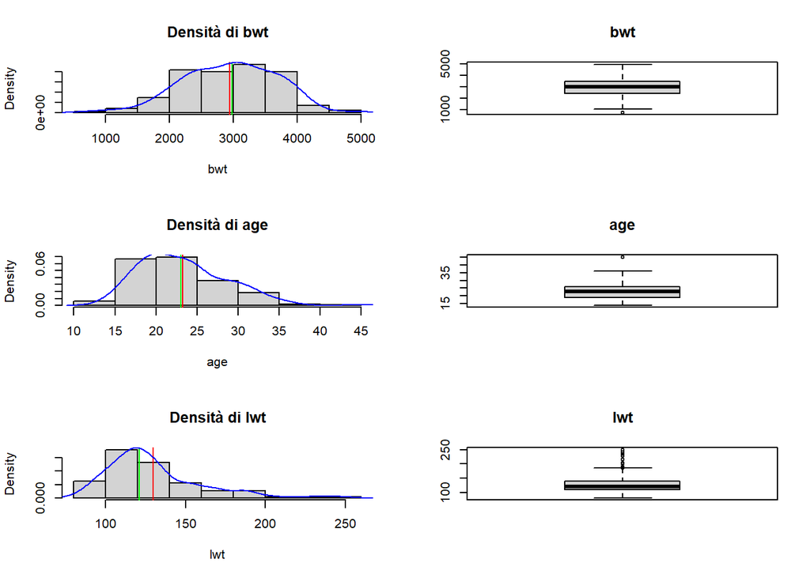

```r
par(mfrow=c(3,2))

gsummary.num("bwt", data=birthwt3, normCurve = F)
gsummary.num("age", data=birthwt3, normCurve = F)
gsummary.num("lwt", data=birthwt3, normCurve = F)
```

```r
par(mfrow=c(2,2))

for (v in c("low", "race", "smoke", "ht", "ui", "ftv")) {
  gsummary.factor(v, data=birthwt3)
}
```

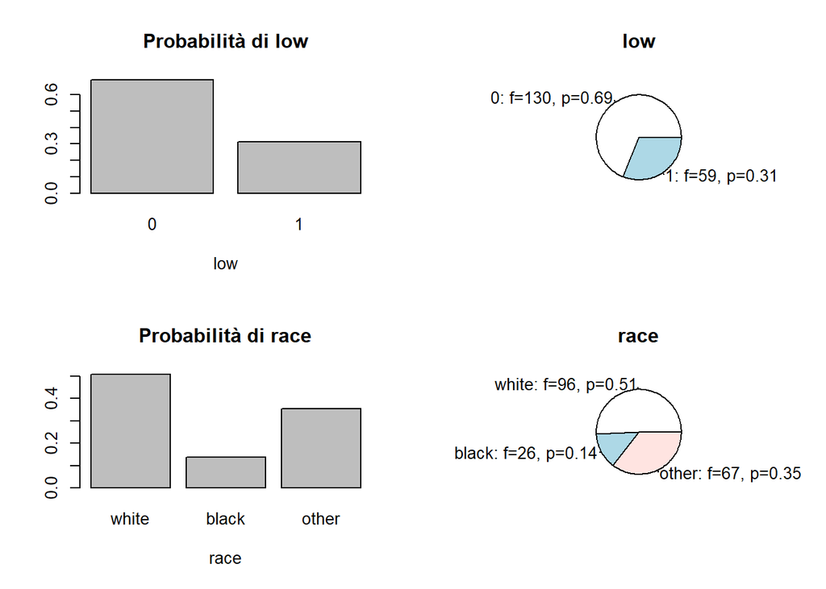

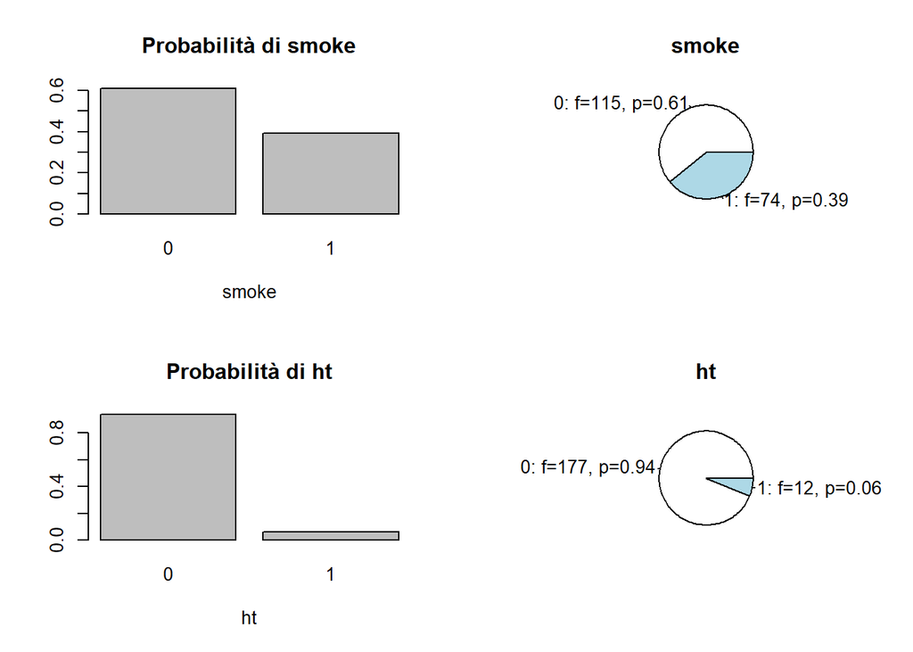

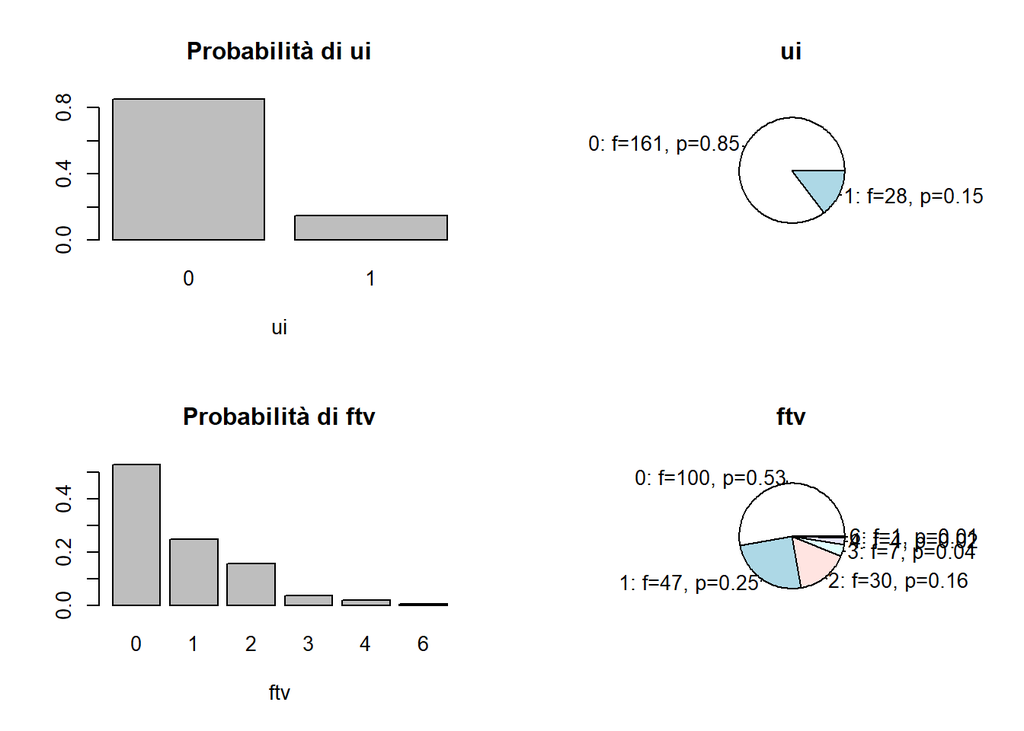

```r
par(mfrow=c(1,1))
```

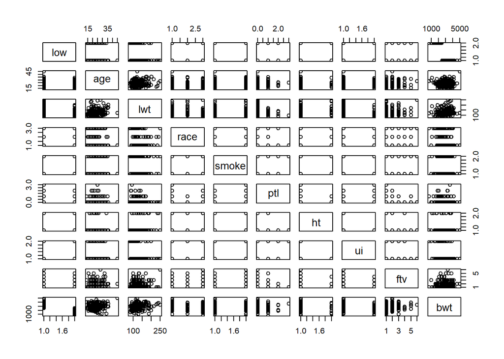

```r
pairs(birthwt3)
```

```r
as.data.frame(cor(birthwt, method = "spearman"))["bwt"]
```

```
##               bwt
## low   -0.80264843
## age    0.06123376
## lwt    0.24888824
## race  -0.18384811
## smoke -0.19760489
## ptl   -0.20367299
## ht    -0.11434529
## ui    -0.26658639
## ftv    0.07114524
## bwt    1.00000000
```

Tramite un brutale calcolo del coefficente di correlazione di spearman tra tutte le variabili e bwt, si può avere un’idea generare rapida di variabili presentano una correlazione con bwt (si esclude da questo plot la variabile race, che essendo non ordinale impedisce questo tipo di analisi). A parte l’ovvia correlazi. con low, si osserva che esiste una leggera correlazione tra bwt e tutti i fattori smoke, plt, ht e ui. Inotltre sembra esserci correlazione con lwt.

Si potrebbero escludere dall’analisi ftv e age, invece sembrano promettenti ui ed lwt. Osservando il plot a coppie (per quanto si riesca a fare) si osservano anche potenziali effetti di collinearità (e.g., tra lwt e ui).